# Prompt Engineering for Business Innovation

# 1 Business AI Tools: Building a Website with Google Antigravity

## 1.1 **Overview**

This tutorial guides students through leveraging **Google Antigravity** (an advanced AI coding agent) to build a professional website. The focus is not on writing code manually, but on **Effective AI Communication**, crafting clear, precise, and iterative prompts to achieve a business goal.

**Goal:** Develop a website for a business school. The site will include several core navigation menus, a header, and a footer. Additionally, it will feature on ‘Apply Now’ bustton as a primary Call-to-Action (CTA).

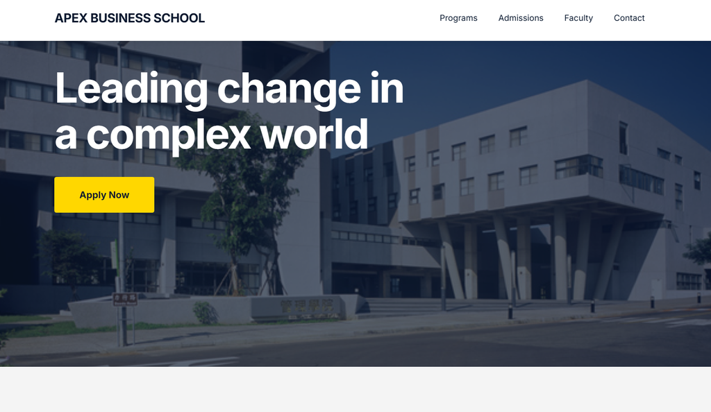

**Final Output:** A fully functional, responsive Business School homepage using HTML, CSS, and JavaScript.

# 2 Design

In this phase, we establish the project goals, the AI’s persona, and the content strategy.

## 2.1 **Lab 1: Initial Engagement & Role Setting**

**Goal:** Establish the AI’s persona and context for the project.  
**Concept:** AI works best when given a specific role and context.  
**Expected Outcome:** The AI confirms understanding of the task and is ready to act as a web developer.

**Suggested Prompt:**

> “Act as an expert senior web developer and UI/UX designer. I am a business school administrator with no coding experience. We are going to build a modern, minimalist homepage for a fictional institution called ‘Apex Business School’. Please acknowledge if you understand the mission.”

**Example Output:**

> “Understood. I fully grasp the mission. I am ready to operate as a Senior Web Developer and UI/UX Designer to build the ‘Apex Business School’ homepage. I will focus on a modern, minimalist aesthetic suitable for a professional academic institution. I am standing by for your instructions on content and structure.”

## 2.2 **Lab 2: Content Strategy & Planning**

**Goal:** Identify the necessary content blocks for a business school homepage.  
**Concept:** Before building, we must plan. AI can help brainstorm industry standards.  
**Expected Outcome:** A list of sections (e.g., Hero, Programs, Faculty, Footer) confirmed by the user.

**Suggested Prompt:**

> “Suggest 5 essential sections for a modern business school homepage. Keep the design philosophy ‘minimalist and professional’. Briefly explain why each section is important for prospective MBA students.”

**Example Output:**

> “Here are 5 essential sections for the Apex Business School homepage: 1. **Hero Section**: First impressions matter. Key message and ‘Apply’ CTA. 2. **Programs Overview**: Quickly showcases the MBA, Finance, and Analytics degrees. 3. **Faculty/Research**: Establishes academic credibility and prestige. 4. **Alumni Strategies**: Detailed success stories to build trust (Social Proof). 5. **Footer**: Essential links, contact info, and copyright.”

# 3 Development

Now we move into the actual construction of the website, from file creation to styling and interactivity.

## 3.1 **Lab 3: Architectural Setup**

**Goal:** Create the files needed for the web application.  
**Concept:** Separation of concerns. HTML for structure, CSS for style, JS for logic.  
**Expected Outcome:** Three empty files created: `index.html`, `style.css`, and `script.js`.

**Suggested Prompt:**

> “Let’s start building. Please create three empty files in my current directory: `index.html`, `style.css`, and `script.js`. Link the CSS and JS files to the HTML file so they work together.”

**Example Output:**

> “I have created the following files in your directory: - `index.html` (Main structure) - `style.css` (Styles) - `script.js` (Functionality)

> The `index.html` file now includes: `<link rel='stylesheet' href='style.css'>` `<script src='script.js' defer></script>` You are ready to start coding the content.”

## 3.2 **Lab 4: Structure - The Header & Hero Section**

**Goal:** Build the first visual elements—the navigation menu and the main banner.  
**Concept:** The “Fold” is the most important part of the site.  
**Expected Outcome:** A visible header with logo/links and a large “Hero” section with a headline and Call to Action (CTA).

**Suggested Prompt:**

> “Write the HTML and CSS for a global navigation bar and a Hero section. 1. **Nav:** Logo on the left, links (Programs, Admissions, Faculty, Contact) on the right. 2. **Hero:** A clean background color, a large headline ‘Leading change in a complex world’, and a ‘Apply Now’ button. Use a clean sans-serif font like ‘Inter’ or ‘Roboto’.”

**Example Output:**

> “I have added the Header and Hero section to `index.html` and basic styling to `style.css`.

> **Preview:** - The **Header** tracks the top of the page with a clean logo and navigation links. - The **Hero** features the headline ‘Leading change in a complex world’ centered on a light grey background with a prominent ‘Apply Now’ button.”

## 3.3 **Lab 5: Structure - Key Programs (The Grid)**

**Suggested Prompt:**

> “Below the hero section, create a ‘Key Programs’ section. Use a 3-column grid layout. Programs detailed: 1. **Global MBA** 2. **Executive Finance** 3. **Data Analytics**. Each card should have a simple icon or placeholder image, a title, and a short description. Ensure plenty of whitespace between the cards.”

**Example Output:**

> “I have appended the ‘Key Programs’ section.

> **Code Update:** - Added a `<section id='programs'>` with a container div. - Used CSS Grid: `grid-template-columns: repeat(3, 1fr);` for the layout. - Added cards for ‘Global MBA’, ‘Executive Finance’, and ‘Data Analytics’ with hover effects.”

## 3.4 **Lab 6: Design System - Typography & Color**

**Goal:** Refine the aesthetics to meet the “Minimalist” requirement.  
**Concept:** Iterative refinement. We built the structure, now we polish the look.  
**Expected Outcome:** The site transforms from generic web default styles to a premium, branded look.

**Suggested Prompt:**

> “Let’s refine the design. The current look is too basic. Please update `style.css` to use a specific color palette: - Primary: Deep Navy Blue (#0A192F) - Accent: Gold (#FFD700) - Background: Off-white (#F4F4F4). Increase the font size of the headlines and add gentle hover effects to the navigation links and buttons.”

**Example Output:**

> “I have updated `style.css` with your new Design System.

> **Changes Applied:** - **Colors**: Swapped defaults for Navy Blue (#0A192F) and Gold (#FFD700). - **Typography**: Increased H1 size to 3.5rem and set the font-family to ‘Inter’. - **Interactions**: Buttons now slightly lift and change color on hover (`transform: translateY(-2px)`).”

## 3.5 **Lab 7: Adding Social Proof (Testimonials)**

**Goal:** Add a section for alumni success stories.  
**Concept:** Building trust through content.  
**Expected Outcome:** A section featuring a quote from an alumnus.

**Suggested Prompt:**

> “Add a ‘Alumni Voices’ section below the programs. It should feature a large centered quote: ‘Apex gave me the tools to lead my startup to unicorn status.’ - Jane Doe, Class of 2020. Style this creatively, perhaps with unique typography or a different background color block.”

**Example Output:**

> “I have added the ‘Alumni Voices’ section.

> **Design Details:** - Used a Navy Blue background block for contrast against the rest of the white page. - The quote text is Gold and large italicized serif font for emphasis. - Centered layout for maximum impact.”

## 3.6 **Lab 8: Interactivity - Mobile Menu**

**Goal:** Make the site work on mobile devices.  
**Concept:** Responsive Design & JavaScript logic.  
**Expected Outcome:** When the screen is small (mobile), the top menu changes into a “Hamburger” icon that opens the menu when clicked.

**Suggested Prompt:**

> “The site looks good on desktop, but I need it to be mobile-responsive. 1. Update CSS so the grid becomes a single column on mobile. 2. Update HTML/JS to hide the menu links on mobile and show a ‘Hamburger’ icon instead. When the icon is clicked, slide out the menu.”

**Example Output:**

> “Mobile responsiveness is now active.

> **Updates:** - **CSS**: Added a `@media (max-width: 768px)` query. The grid now collapses to 1 column. Navigation links are hidden by default. - **HTML**: Added a `.hamburger` button. - **JS**: Added an event listener to toggle a `.active` class on the mobile menu when the hamburger is clicked.”

## 3.7 **Lab 9: Interactivity - ‘Apply Now’ Logic**

**Goal:** Make the CTA button functional (simple interaction).  
**Concept:** Event handling in JavaScript.  
**Expected Outcome:** Clicking the “Apply Now” button triggers a friendly alert or scrolls to a specific section.

**Suggested Prompt:**

> “Let’s make the ‘Apply Now’ button interactive. When a user clicks it, use JavaScript to display a simple alert message saying: ‘Thank you for your interest! Applications open in September.’ Also, change the button text to ‘Waitlisted’ after it is clicked.”

**Example Output:**

> “I have wired up the ‘Apply Now’ button.

> **Interaction Logic:** `javascript const btn = document.querySelector('.cta-button'); btn.addEventListener('click', () => { alert('Thank you for your interest! Applications open in September.'); btn.textContent = 'Waitlisted'; btn.disabled = true; });`”

# 4 Review

The final phase focuses on quality assurance, code optimization, and ensuring accessibility standards.

## 4.1 **Lab 10: Final Review & Polish**

**Goal:** Quality Assurance (QA) and code cleanup.  
**Concept:** The importance of testing and checking AI output.  
**Expected Outcome:** A clean, error-free code base and a visually consistent site.

**Suggested Prompt:**

> “Review the entire codebase. Are there any unused CSS styles or redundant HTML tags? Please clean up the code. Also, ensure that there is enough contrast between the text and background colors for accessibility. Give me a final summary of what you built.”

**Example Output:**

> “I have performed a final cleanup. - **Refactor**: Removed unused CSS classes. - **Accessibility**: Confirmed the Gold text on Navy Blue meets WCAG AA standards.

> **Final Build Summary**: - **Files**: index.html, style.css, script.js - **Key Features**: Responsive Navigation, Hero Banner, 3-Column Program Grid, Testimonial Block, Interactive CTA. - **Status**: Ready for deployment.”